# Exercise Prediction Write Up

MT

1/8/2021

```r
library(knitr)
library(caret)
```

```r
library(rpart)
library(rpart.plot)
library(rattle)
library(randomForest)
library(corrplot)
set.seed(301)
```

#Data Loading and Exploratory Analysis

```r
library(xlsx); library(caret)
training<- read.csv(file = "pml-training.csv")
test<- read.csv("pml-testing.csv")
head(training)
```

```
##   X user_name raw_timestamp_part_1 raw_timestamp_part_2   cvtd_timestamp
## 1 1  carlitos           1323084231               788290 05/12/2011 11:23
## 2 2  carlitos           1323084231               808298 05/12/2011 11:23
## 3 3  carlitos           1323084231               820366 05/12/2011 11:23
## 4 4  carlitos           1323084232               120339 05/12/2011 11:23
## 5 5  carlitos           1323084232               196328 05/12/2011 11:23
## 6 6  carlitos           1323084232               304277 05/12/2011 11:23
##   new_window num_window roll_belt pitch_belt yaw_belt total_accel_belt
## 1         no         11      1.41       8.07    -94.4                3
## 2         no         11      1.41       8.07    -94.4                3
## 3         no         11      1.42       8.07    -94.4                3
## 4         no         12      1.48       8.05    -94.4                3
## 5         no         12      1.48       8.07    -94.4                3
## 6         no         12      1.45       8.06    -94.4                3
##   kurtosis_roll_belt kurtosis_picth_belt kurtosis_yaw_belt skewness_roll_belt
```

[output cut: 251 more lines]

```r
dim(training)
```

```
## [1] 19622   160
```

```r
summary(training)
```

```
##        X          user_name         raw_timestamp_part_1 raw_timestamp_part_2
##  Min.   :    1   Length:19622       Min.   :1.322e+09    Min.   :   294
##  1st Qu.: 4906   Class :character   1st Qu.:1.323e+09    1st Qu.:252912
##  Median : 9812   Mode  :character   Median :1.323e+09    Median :496380
##  Mean   : 9812                      Mean   :1.323e+09    Mean   :500656
##  3rd Qu.:14717                      3rd Qu.:1.323e+09    3rd Qu.:751891
##  Max.   :19622                      Max.   :1.323e+09    Max.   :998801
##
##  cvtd_timestamp      new_window          num_window      roll_belt
##  Length:19622       Length:19622       Min.   :  1.0   Min.   :-28.90
##  Class :character   Class :character   1st Qu.:222.0   1st Qu.:  1.10
##  Mode  :character   Mode  :character   Median :424.0   Median :113.00
##                                        Mean   :430.6   Mean   : 64.41
##                                        3rd Qu.:644.0   3rd Qu.:123.00
##                                        Max.   :864.0   Max.   :162.00
##
##    pitch_belt          yaw_belt       total_accel_belt kurtosis_roll_belt
##  Min.   :-55.8000   Min.   :-180.00   Min.   : 0.00    Length:19622
##  1st Qu.:  1.7600   1st Qu.: -88.30   1st Qu.: 3.00    Class :character
##  Median :  5.2800   Median : -13.00   Median :17.00    Mode  :character
##  Mean   :  0.3053   Mean   : -11.21   Mean   :11.31
##  3rd Qu.: 14.9000   3rd Qu.:  12.90   3rd Qu.:18.00
##  Max.   : 60.3000   Max.   : 179.00   Max.   :29.00
##
##  kurtosis_picth_belt kurtosis_yaw_belt  skewness_roll_belt skewness_roll_belt.1
##  Length:19622        Length:19622       Length:19622       Length:19622
##  Class :character    Class :character   Class :character   Class :character
##  Mode  :character    Mode  :character   Mode  :character   Mode  :character
##
##
##
##
##  skewness_yaw_belt  max_roll_belt     max_picth_belt  max_yaw_belt
##  Length:19622       Min.   :-94.300   Min.   : 3.00   Length:19622
##  Class :character   1st Qu.:-88.000   1st Qu.: 5.00   Class :character
##  Mode  :character   Median : -5.100   Median :18.00   Mode  :character
##                     Mean   : -6.667   Mean   :12.92
##                     3rd Qu.: 18.500   3rd Qu.:19.00
##                     Max.   :180.000   Max.   :30.00
##                     NA's   :19216     NA's   :19216
```

[output cut: 289 more lines]

```
##  Min.   :-446.00   Min.   :-1280.0   Min.   :-896.0   Min.   :-973.0
##  1st Qu.:-182.00   1st Qu.: -616.0   1st Qu.:   2.0   1st Qu.: 191.0
##  Median : -39.00   Median : -378.0   Median : 591.0   Median : 511.0
##  Mean   : -55.29   Mean   : -312.6   Mean   : 380.1   Mean   : 393.6
##  3rd Qu.:  26.00   3rd Qu.:  -73.0   3rd Qu.: 737.0   3rd Qu.: 653.0
##  Max.   : 291.00   Max.   :  672.0   Max.   :1480.0   Max.   :1090.0
##
##     classe
##  Length:19622
##  Class :character
##  Mode  :character
##
##
##
##
```

#Partioning Training Data

```r
intrain<- createDataPartition(training$classe, p=0.7, list=F)
trainset<- training[intrain, ]
testset<- training[-intrain,]
dim(trainset)
```

```
## [1] 13737   160
```

```r
dim(testset)
```

```
## [1] 5885  160
```

Cleaning up NA values, near zero variance and ID variables present within dataset.

```r
nzv<- nearZeroVar(trainset)
trainset<- trainset[,-nzv]
testset<- testset[,-nzv]
dim(testset)
```

```
## [1] 5885  105
```

```r
dim(trainset)
```

```
## [1] 13737   105
```

Removing varibles that are filled with NA

```r
allna<- sapply(trainset, function(x) mean(is.na(x))) > 0.95
trainset<- trainset[,allna==F]
testset<- testset[,allna==F]
head(trainset)
```

```
##     X user_name raw_timestamp_part_1 raw_timestamp_part_2   cvtd_timestamp
## 1   1  carlitos           1323084231               788290 05/12/2011 11:23
## 2   2  carlitos           1323084231               808298 05/12/2011 11:23
## 3   3  carlitos           1323084231               820366 05/12/2011 11:23
## 4   4  carlitos           1323084232               120339 05/12/2011 11:23
## 9   9  carlitos           1323084232               484323 05/12/2011 11:23
## 10 10  carlitos           1323084232               484434 05/12/2011 11:23
##    num_window roll_belt pitch_belt yaw_belt total_accel_belt gyros_belt_x
## 1          11      1.41       8.07    -94.4                3         0.00
## 2          11      1.41       8.07    -94.4                3         0.02
## 3          11      1.42       8.07    -94.4                3         0.00
## 4          12      1.48       8.05    -94.4                3         0.02
## 9          12      1.43       8.16    -94.4                3         0.02
## 10         12      1.45       8.17    -94.4                3         0.03
##    gyros_belt_y gyros_belt_z accel_belt_x accel_belt_y accel_belt_z
```

[output cut: 69 more lines]

Removing identification of the variables

```r
trainset<- trainset[,-(1:5)]
testset<- testset[,-(1:5)]
dim(testset)
```

```
## [1] 5885   54
```

```r
dim(trainset)
```

```
## [1] 13737    54
```

```r
head(trainset)
```

```
##    num_window roll_belt pitch_belt yaw_belt total_accel_belt gyros_belt_x
## 1          11      1.41       8.07    -94.4                3         0.00
## 2          11      1.41       8.07    -94.4                3         0.02
## 3          11      1.42       8.07    -94.4                3         0.00
## 4          12      1.48       8.05    -94.4                3         0.02
## 9          12      1.43       8.16    -94.4                3         0.02
## 10         12      1.45       8.17    -94.4                3         0.03
##    gyros_belt_y gyros_belt_z accel_belt_x accel_belt_y accel_belt_z
## 1             0        -0.02          -21            4           22
## 2             0        -0.02          -22            4           22
## 3             0        -0.02          -20            5           23
## 4             0        -0.03          -22            3           21
## 9             0        -0.02          -20            2           24
## 10            0         0.00          -21            4           22
##    magnet_belt_x magnet_belt_y magnet_belt_z roll_arm pitch_arm yaw_arm
```

[output cut: 62 more lines]

#Correaltion Analysis of the Varibles

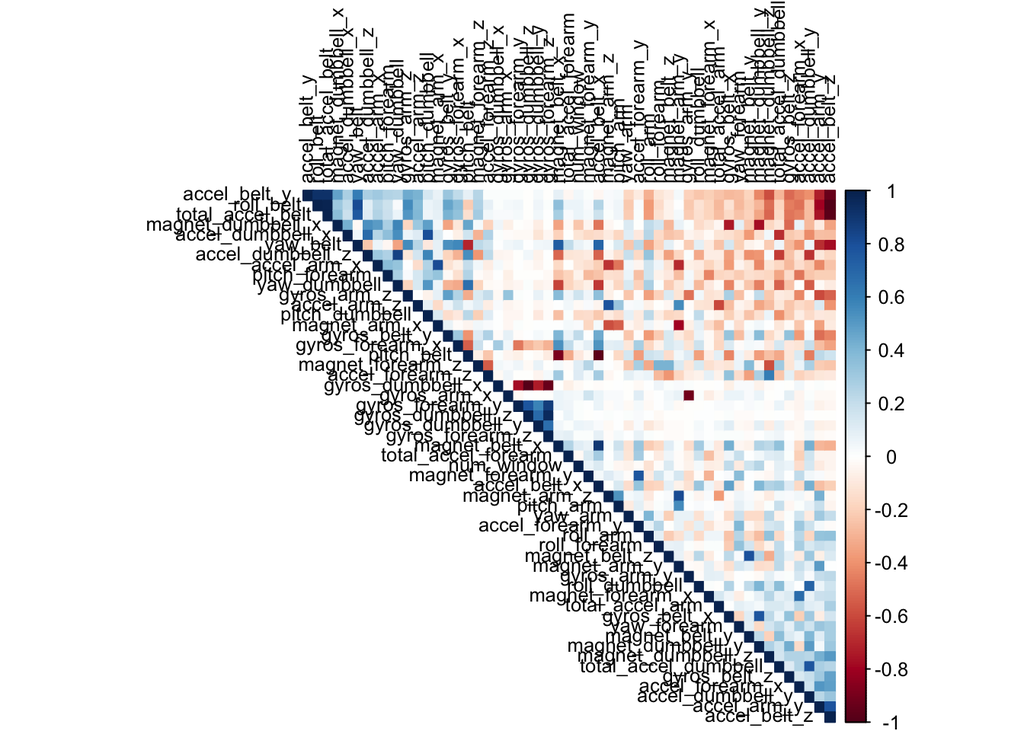

```r
cmatrix<- cor(trainset[,-54])
corrplot(cmatrix, order= "FPC", method = "color", type= "upper", tl.cex = 0.8, tl.col = rgb(0,0,0))
```

Based on the observations, the darker the colour the stronger their correlation. Using PCA can help further narrow down which variable to eliminate. However, for this assignment we will skip that step as there aren’t too many that are correlated.

#Prediction Model Building ##Random Forest Training the model

```r
set.seed(100)
controlrf<- trainControl(method="cv", number=10, verboseIter = F)
modrf<- train(classe~., data= trainset, method = "rf", trControl=controlrf)
modrf$finalModel
```

```
##
## Call:
##  randomForest(x = x, y = y, mtry = param$mtry)
##                Type of random forest: classification
##                      Number of trees: 500
## No. of variables tried at each split: 27
##
##         OOB estimate of  error rate: 0.21%
## Confusion matrix:
##      A    B    C    D    E  class.error
## A 3904    1    0    0    1 0.0005120328
## B    6 2648    3    1    0 0.0037622272
## C    0    5 2390    1    0 0.0025041736
## D    0    0    7 2245    0 0.0031083481
## E    0    1    0    3 2521 0.0015841584
```

Predicting using the RF model

```r
predictrf<- predict(modrf,newdata= testset)
matrixrf<- confusionMatrix(as.factor(predictrf), as.factor(testset$classe))
matrixrf
```

```
## Confusion Matrix and Statistics
##
##           Reference
## Prediction    A    B    C    D    E
##          A 1674    2    0    0    0
##          B    0 1136    0    0    0
##          C    0    1 1026    2    0
##          D    0    0    0  962    4
##          E    0    0    0    0 1078
##
## Overall Statistics
##
##                Accuracy : 0.9985
##                  95% CI : (0.9971, 0.9993)
##     No Information Rate : 0.2845
##     P-Value [Acc > NIR] : < 2.2e-16
##
##                   Kappa : 0.9981
##
##  Mcnemar's Test P-Value : NA
##
## Statistics by Class:
##
##                      Class: A Class: B Class: C Class: D Class: E
## Sensitivity            1.0000   0.9974   1.0000   0.9979   0.9963
## Specificity            0.9995   1.0000   0.9994   0.9992   1.0000
## Pos Pred Value         0.9988   1.0000   0.9971   0.9959   1.0000
## Neg Pred Value         1.0000   0.9994   1.0000   0.9996   0.9992
## Prevalence             0.2845   0.1935   0.1743   0.1638   0.1839
## Detection Rate         0.2845   0.1930   0.1743   0.1635   0.1832
## Detection Prevalence   0.2848   0.1930   0.1749   0.1641   0.1832
## Balanced Accuracy      0.9998   0.9987   0.9997   0.9986   0.9982
```

Analysis of Matrix

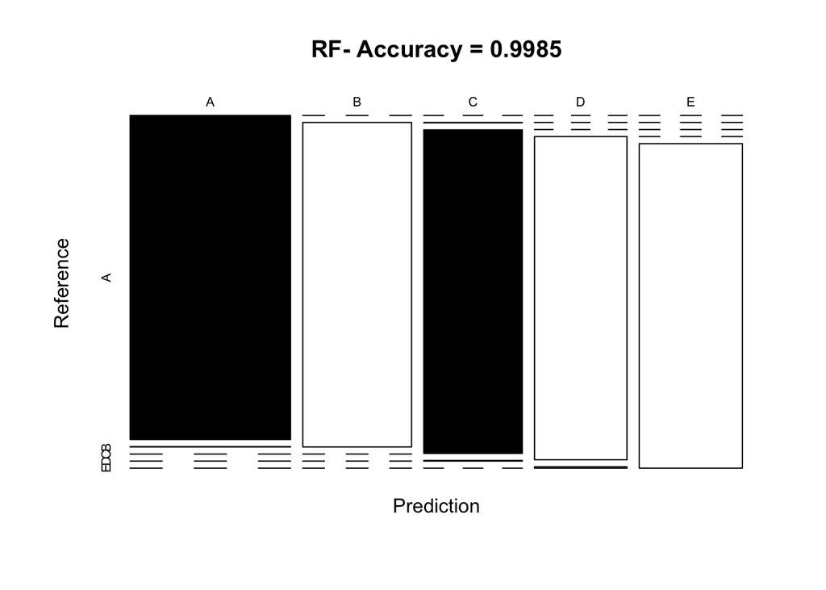

```r
plot(matrixrf$table, col=matrixrf$byClass, main= paste("RF- Accuracy =", round(matrixrf$overall['Accuracy'],4)))
```

##Decision Tree Creating Model using DT on training set

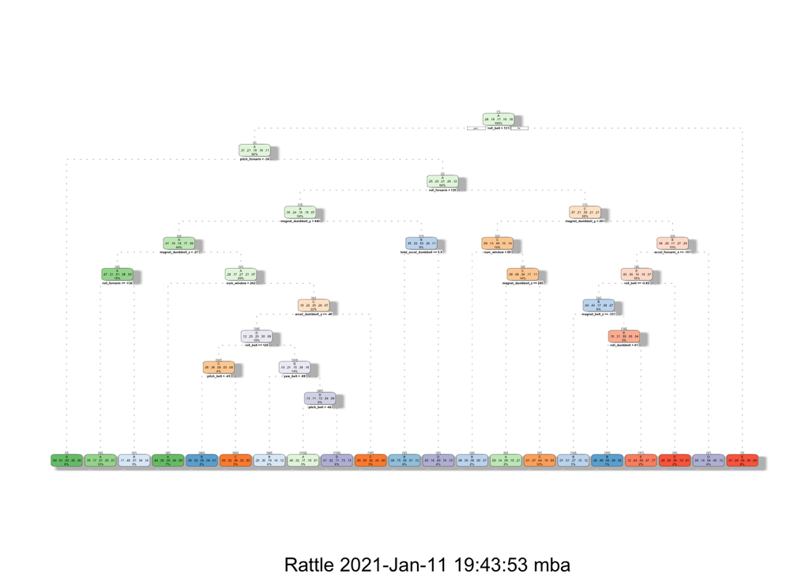

```r
set.seed(100)
moddt<- rpart(classe~., data=trainset, method="class")
fancyRpartPlot(moddt)
```

Using model on test set

```r
predictdt<- predict(moddt, newdata= testset, type="class")
matrixdt<- confusionMatrix(predictdt,as.factor(testset$classe))
matrixdt
```

```
## Confusion Matrix and Statistics
##
##           Reference
## Prediction    A    B    C    D    E
##          A 1497  209   55   73   76
##          B  128  781  156  180  184
##          C    8   56  780  107   68
##          D   25   84   35  571   90
##          E   16    9    0   33  664
##
## Overall Statistics
##
##                Accuracy : 0.7295
##                  95% CI : (0.7179, 0.7408)
##     No Information Rate : 0.2845
##     P-Value [Acc > NIR] : < 2.2e-16
##
##                   Kappa : 0.6556
##
##  Mcnemar's Test P-Value : < 2.2e-16
##
## Statistics by Class:
##
##                      Class: A Class: B Class: C Class: D Class: E
## Sensitivity            0.8943   0.6857   0.7602  0.59232   0.6137
## Specificity            0.9019   0.8635   0.9508  0.95245   0.9879
## Pos Pred Value         0.7838   0.5465   0.7655  0.70932   0.9197
## Neg Pred Value         0.9555   0.9197   0.9494  0.92264   0.9190
## Prevalence             0.2845   0.1935   0.1743  0.16381   0.1839
## Detection Rate         0.2544   0.1327   0.1325  0.09703   0.1128
## Detection Prevalence   0.3246   0.2428   0.1732  0.13679   0.1227
## Balanced Accuracy      0.8981   0.7746   0.8555  0.77239   0.8008
```

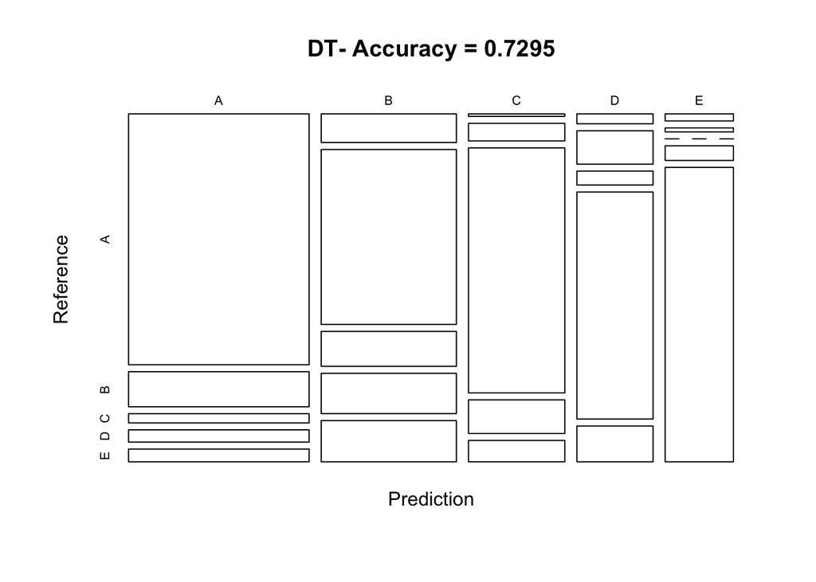

```r
plot(matrixdt$table, col=matrixdt$byClass, main= paste("DT- Accuracy =", round(matrixdt$overall['Accuracy'], 4)))
```

##Generalised Boosted Model (GBM)

```r
set.seed(100)
controlgbm<- trainControl(method="repeatedcv", number = 3 , repeats=1)
modgbm<- train(classe~., data=trainset,method="gbm", trControl=controlgbm, verbose=F)
modgbm$finalModel
```

```
## A gradient boosted model with multinomial loss function.
## 150 iterations were performed.
## There were 53 predictors of which 52 had non-zero influence.
```

```r
#predicting model
predictgbm<- predict(modgbm, newdata=testset)
matrixgbm<- confusionMatrix(predictgbm, as.factor(testset$classe))
matrixgbm
```

```
## Confusion Matrix and Statistics
##
##           Reference
## Prediction    A    B    C    D    E
##          A 1672    6    0    1    0
##          B    2 1119    4   11    4
##          C    0   12 1017    8    4
##          D    0    2    3  944    8
##          E    0    0    2    0 1066
##
## Overall Statistics
##
##                Accuracy : 0.9886
##                  95% CI : (0.9856, 0.9912)
##     No Information Rate : 0.2845
##     P-Value [Acc > NIR] : < 2.2e-16
##
##                   Kappa : 0.9856
##
##  Mcnemar's Test P-Value : NA
##
## Statistics by Class:
##
##                      Class: A Class: B Class: C Class: D Class: E
## Sensitivity            0.9988   0.9824   0.9912   0.9793   0.9852
## Specificity            0.9983   0.9956   0.9951   0.9974   0.9996
## Pos Pred Value         0.9958   0.9816   0.9769   0.9864   0.9981
## Neg Pred Value         0.9995   0.9958   0.9981   0.9959   0.9967
## Prevalence             0.2845   0.1935   0.1743   0.1638   0.1839
## Detection Rate         0.2841   0.1901   0.1728   0.1604   0.1811
## Detection Prevalence   0.2853   0.1937   0.1769   0.1626   0.1815
## Balanced Accuracy      0.9986   0.9890   0.9931   0.9883   0.9924
```

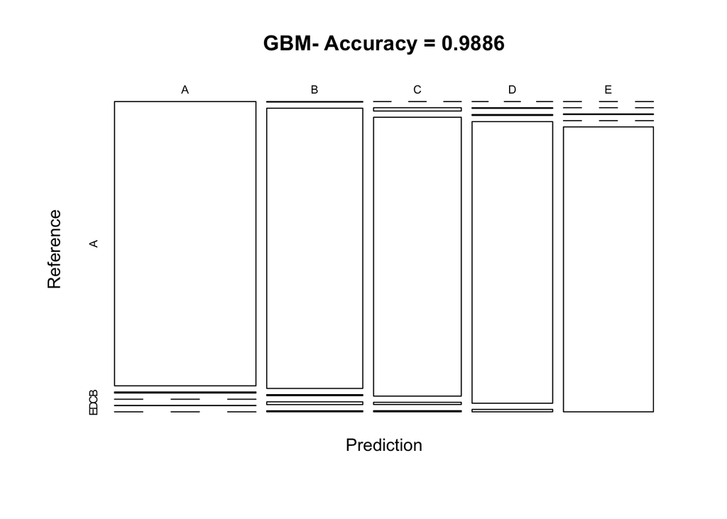

```r
#ploting gbm model
plot(matrixgbm$table, col=matrixgbm$byClass, main=paste("GBM- Accuracy =", round(matrixgbm$overall['Accuracy'],4)))
```

Comparing the accuracy between each of the model generated, random forest seems to be the one with the highest accuracy. Hence, it will be selected as the model to test on the test set data.

```r
predicttest<- predict(modrf, newdata=test)
predicttest
```

```
##  [1] B A B A A E D B A A B C B A E E A B B B
## Levels: A B C D E
```